# Next-Word Prediction: Building and Evaluating the Model

Hein Htet Linn Nyan

2026-09-24

## Summary

The model suggests the next word from the last three words typed. The best version tested puts the correct word in its top three suggestions 24% of the time. The version chosen for the app is nearly as accurate (24%), takes 18.5 MB of memory and returns suggestions in 8.52 milliseconds.

## How the model works

The model learns from counts of short word sequences (n-grams) in the training text: single words, and runs of two, three and four words. To predict, it looks up the last three words typed and finds which words most often followed them. If that three-word phrase never appeared in training, it drops the oldest word and tries again with two, then one. Each step down is scored lower, so matches on longer phrases win. This method is called “stupid backoff”. It is simple and fast, and works well on large text collections.

Words seen only once in training are treated as a single “unknown word” token. Only the top five candidates for each phrase are kept, since the app shows three.

## How it was tested

Before training, 5,000 lines were set aside and never used to build the model. From these, 20,000 positions were picked at random. At each one, the model was given the preceding words and asked for the next.

Four measures were recorded:

- **Top-1, top-2, top-3 accuracy:** how often the correct word was the first suggestion, in the first two, or in the first three.
- **Perplexity:** how surprised the model is by the real text, on average. Lower is better.
- **Speed:** milliseconds per prediction, averaged over 300 single predictions.
- **Size:** memory used by the tables the app needs.

## Results

| Training data | Min count | Size (MB) | ms / pred | Top-1 | Top-2 | Top-3 | Perplexity |
| --- | --- | --- | --- | --- | --- | --- | --- |
| 1% | 1 | 111.9 | 7.97 | 11.9% | 17.1% | 20.6% | 621.4 |
| 1% | 2 | 7.0 | 7.31 | 13.3% | 18.9% | 22.3% | 594.3 |
| 1% | 4 | 3.0 | 7.36 | 12.6% | 18.0% | 21.5% | 661.6 |
| 3% | 1 | 294.7 | 8.80 | 13.0% | 18.6% | 22.4% | 573.5 |
| 3% | 2 | 18.5 | 8.52 | 14.4% | 20.4% | 24.0% | 558.1 |
| 3% | 4 | 7.1 | 7.96 | 13.9% | 19.7% | 23.2% | 633.6 |

### More data or a bigger model?

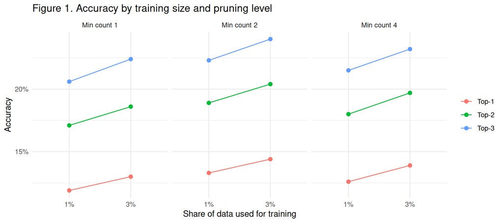

More training data raises accuracy at every pruning level. The gain is modest, which is typical: common phrases are learned from a small sample, and more data mostly adds rare ones.

### Does accuracy cost speed?

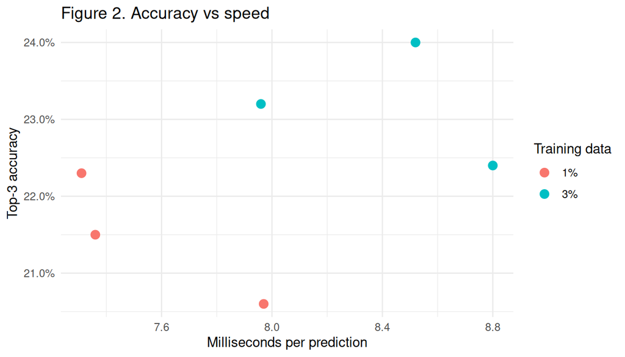

Prediction time ranged from 7.31 to 8.8 ms. All versions are fast enough to update as the user types. Speed is not the limit here; memory is.

### Does perplexity agree with accuracy?

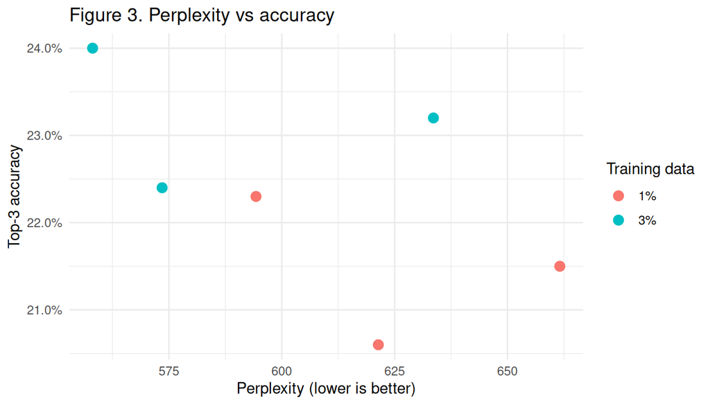

The correlation between perplexity and accuracy was -0.49 for top-1 and -0.56 for top-3. A negative value means lower perplexity goes with higher accuracy, as expected. The match is not exact, for two reasons. Perplexity scores the probability the model gives the right word, while accuracy only asks whether the right word made the top three. And each training size has its own vocabulary, which shifts perplexity in ways that do not affect accuracy.

### Can the model be made smaller?

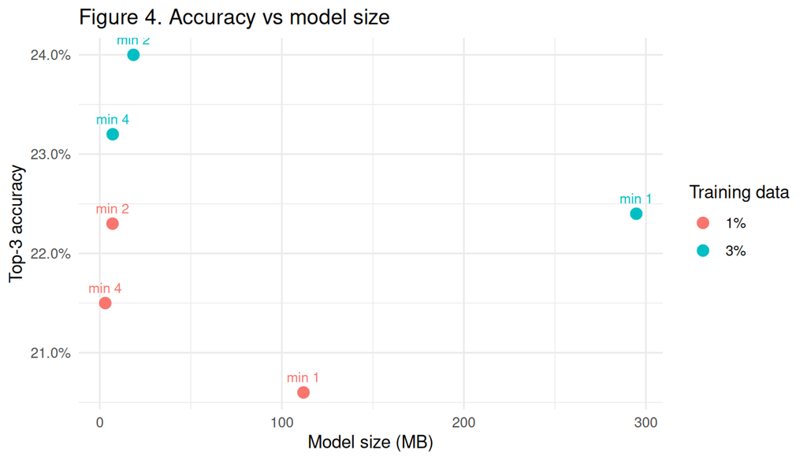

## Chosen model

The app will use the model trained on 3% of the data with a minimum count of 2. It is the smallest version within half a percentage point of the best accuracy.

Table 2. Example suggestions from the chosen model

| Typed text | Suggestions |
| --- | --- |
| thanks for the | follow, rt, mention |
| I want to | be, go, see |
| at the end of the | day, year, month |
| let me know if | you, u, i |
| happy mothers | day, and, of |
| see you | there, at, soon |

## Next steps

- Build the Shiny app around this model: a text box, with three suggested words that update as the user types.
- Try weighting each source (blogs, news, Twitter) equally in training. Twitter lines currently dominate because the file has the most lines.
- Filter profanity from the suggestions.

## Appendix: code

```r
knitr::opts_chunk$set(echo = FALSE, message = FALSE, warning = FALSE)
library(data.table)
library(stringi)
library(ggplot2)
library(knitr)
# Runs the full modelling script only if its results are not already saved
if (!file.exists("output/model_results.csv")) source("next_word_model.R")
res <- fread("output/model_results.csv")

res[, train_pct := paste0(round(100 * train_frac), "%")]

best_top3 <- max(res$top3)
# Smallest model within half a percentage point of the best top-3 accuracy
chosen <- res[top3 >= best_top3 - 0.005][order(app_mb)][1]

largest   <- res[train_frac == max(train_frac)]
unpruned  <- largest[min_count == min(min_count)]
pruned    <- largest[min_count == max(min_count)]
size_drop <- round(100 * (1 - pruned$app_mb / unpruned$app_mb))
acc_drop  <- round(100 * (unpruned$top3 - pruned$top3), 1)

fastest <- res[which.min(ms_per_pred)]
slowest <- res[which.max(ms_per_pred)]

r_top1 <- round(cor(res$perplexity, res$top1), 2)
r_top3 <- round(cor(res$perplexity, res$top3), 2)
res[, .(`Training data` = train_pct,
        `Min count`     = min_count,
        `Size (MB)`     = app_mb,
        `ms / pred`     = ms_per_pred,
        `Top-1`         = sprintf("%.1f%%", 100 * top1),
        `Top-2`         = sprintf("%.1f%%", 100 * top2),
        `Top-3`         = sprintf("%.1f%%", 100 * top3),
        Perplexity      = perplexity)] |>
  kable(caption = "Table 1. All nine model versions")
res |>
  melt(id.vars = c("train_pct", "min_count"),
       measure.vars = c("top1", "top2", "top3"),
       variable.name = "measure", value.name = "accuracy") |>
  ggplot(aes(train_pct, accuracy, colour = measure, group = measure)) +
  geom_line() +
  geom_point(size = 2) +
  facet_wrap(~ min_count, labeller = labeller(min_count = function(x) paste("Min count", x))) +
  scale_y_continuous(labels = scales::percent) +
  scale_colour_discrete(labels = c("Top-1", "Top-2", "Top-3")) +
  labs(x = "Share of data used for training", y = "Accuracy", colour = NULL,
       title = "Figure 1. Accuracy by training size and pruning level") +
  theme_minimal()
ggplot(res, aes(ms_per_pred, top3, colour = train_pct)) +
  geom_point(size = 3) +
  scale_y_continuous(labels = scales::percent) +
  labs(x = "Milliseconds per prediction", y = "Top-3 accuracy", colour = "Training data",
       title = "Figure 2. Accuracy vs speed") +
  theme_minimal()
ggplot(res, aes(perplexity, top3, colour = train_pct)) +
  geom_point(size = 3) +
  scale_y_continuous(labels = scales::percent) +
  labs(x = "Perplexity (lower is better)", y = "Top-3 accuracy", colour = "Training data",
       title = "Figure 3. Perplexity vs accuracy") +
  theme_minimal()
ggplot(res, aes(app_mb, top3, colour = train_pct)) +
  geom_point(size = 3) +
  geom_text(aes(label = paste("min", min_count)), vjust = -1, size = 3, show.legend = FALSE) +
  scale_y_continuous(labels = scales::percent) +
  labs(x = "Model size (MB)", y = "Top-3 accuracy", colour = "Training data",
       title = "Figure 4. Accuracy vs model size") +
  theme_minimal()
MAX_ORDER <- 4
ALPHA     <- 0.4

clean_text <- function(x) {
  x |>
    stri_trans_tolower() |>
    stri_replace_all_regex("https?://\\S+|www\\.\\S+", " ") |>
    stri_replace_all_regex("[\\u2018\\u2019]", "'") |>
    stri_replace_all_regex("[^a-z' ]", " ") |>
    stri_replace_all_regex("(^| )'+|'+( |$)", " ") |>
    stri_replace_all_regex(" +", " ") |>
    stri_trim_both()
}

map_vocab <- function(w, vocab) {
  w[!(w %chin% vocab)] <- "<unk>"
  w
}

ctx_key <- function(cases, n) {
  if (n == 1) return(rep("", nrow(cases)))
  parts <- lapply(rev(seq_len(n - 1)), function(k) cases[[paste0("w", k)]])
  key <- do.call(paste, parts)
  key[Reduce(`|`, lapply(parts, is.na))] <- NA_character_
  key
}

predict_batch <- function(model, cases, k = 3) {
  parts <- list()
  for (n in MAX_ORDER:2) {
    q <- data.table(id = cases$id, prefix = ctx_key(cases, n))[!is.na(prefix)]
    hit <- model$pred[[n]][q, on = "prefix", nomatch = 0L, allow.cartesian = TRUE]
    if (nrow(hit)) parts[[length(parts) + 1]] <-
      hit[, .(id, word, score = ALPHA^(MAX_ORDER - n) * p)]
  }
  u <- model$pred[[1]]
  parts[[length(parts) + 1]] <- data.table(
    id    = rep(cases$id, each = nrow(u)),
    word  = rep(u$word, times = nrow(cases)),
    score = rep(ALPHA^(MAX_ORDER - 1) * u$p, times = nrow(cases))
  )
  cand <- rbindlist(parts)[, .(score = max(score)), by = .(id, word)]
  setorder(cand, id, -score)
  cand[, rank := rowid(id)][rank <= k]
}

predict_next <- function(model, phrase, k = 3) {
  w <- stri_split_fixed(clean_text(phrase), " ", omit_empty = TRUE)[[1]] |>
    map_vocab(model$vocab) |>
    rev()
  cases <- data.table(id = 1L,
                      w1 = as.character(w[1]),
                      w2 = as.character(w[2]),
                      w3 = as.character(w[3]))
  predict_batch(model, cases, k)$word
}

model <- readRDS(sprintf("models/model_f%.2f_mc%d.rds", chosen$train_frac, chosen$min_count))

examples <- c("thanks for the", "I want to", "at the end of the",
              "let me know if", "happy mothers", "see you")

data.table(`Typed text`  = examples,
           Suggestions = vapply(examples,
                                function(x) paste(predict_next(model, x), collapse = ", "),
                                character(1))) |>
  kable(caption = "Table 2. Example suggestions from the chosen model")
```